# Exploring Linguistic Diversity Using R

## Amir Barghi

### Mathematics and Statistics

## Social Science Seminar

### Thursday, October 20

# Introduction

Greenberg (1956) defined linguistic diversity as the probability that two randomly chosen individuals (with replacement) from a population have different first languages. In other words, if there are $n$ languages in a population and $p_i$ denotes the probability that an individual chosen at random from this population has the $i$th language as their first language, for $i \in \{1,\ldots,n\}$, then Greenberg's index of linguistic diversity (LDI) is calculated as $$ H_2 = 1 - \sum_{i=1} ^n p_i^2.$$

- M. J. H. Greenberg, The measurement of linguistic diversity, *Language*, vol. 32, pp. 109--115, Jan.-Mar. 1956.

In ecology, $H_2$ is known as Gini-Simpson index (named after Italian Statistician, [Corrado Gini](https://www.britannica.com/biography/Corrado-Gini), and after Edward Hugh Simpson (1949)), and as discussed by Jost (2006), it is measure of entropy (or uncertainty) and not diversity. According to Jost (2006), a diversity index should measure "the effective number of elements in a system." In ecology, this is **the number of equiprobable species in a population having the same entropic index**.

- E. Simpson, Measurement of diversity, *Nature*, vol 163, p. 688, April 1949.
- L. Jost, Entropy and diversity, *Oikos*, vol. 113, pp. 363--375, Jan. 2006.

Jost (2006) shows that, in order to use the Gini-Simpson index (or equivalently, LDI) as a measure of diversity, one needs to consider the following transformation of $H_2$: $$ D_2 = \frac{1}{1-H_2} = \frac{1}{\sum_{i=1} ^n p_i ^2}.$$ This is also known as the *effective number* of a population which was introduced by MacArthur (1965).

- L. Jost, Entropy and diversity, *Oikos*, vol. 113, pp. 363--375, Jan. 2006.
- R. H. MacArthur, Patterns of species diversity, *Biol. Rev. Camb. Philos. Soc.*, vol. 40, pp. 510--533, Nov. 1965.

# Preliminaries

Here we discuss different entropic indices and how to transform them into diversity measures, i.e., effective numbers. Throughout this exploration, we will use diversity and effective number interchangeably. We also assume that there are $n$ languages in a population or a country, and $p_i$ denotes the probability that an individual chosen at random from this population has the $i$th language as their first language, for $i \in \{1,\ldots,n\}$. We denote an entropy and a diversity by $H_q$ and $D_q$, respectively, where $q$ denotes the order of the entropy and of the diversity.

## Richness

Linguistic richness is the simplest measure of diversity and it counts the number of languages in a country. In mathematical terms, the entropic index is defined as $$ H_0 = \sum_{i = 1} ^n p_i ^0,$$ and it is not difficult to see that its effective number is $$D_0 = \sum_{i = 1} ^n p_i ^0.$$

## Shannon

Shannon entropy, the very first measure of entropy in the context of information theory, was introduced by Shannon (1948). It is defined as $$H_1 = \sum_{i=1} ^n p_i \ln(p_i),$$ and it measures the expected value of uncertainty in a system. Hill (1973) shows that the effective number of this entropy is calculated as $$ D_1 = \exp(H_1) = \exp\left( - \sum_{i=1} ^n p_i \ln(p_i) \right).$$

- C. E. Shannon, A mathematical theory of communication, *Bell System Tech. J.*, vol. 27, pp. 379--423, 623--656, July, October, 1948.
- M. Hill, Diversity and evenness: a unifying notation and its consequences, *Ecology*, vol. 54, p. 427---432, Mar. 1973.

## Greenberg/Gini-Simpson

We saw earlier that Greenberg's index of linguistic diversity and Gini-Simpson index in ecology are the same, and we discussed how to transform them into effective numbers: $$ H_2 = 1 - \sum_{i=1} ^n p_i^2$$ and $$ D_2 = \frac{1}{1-H_2} = \frac{1}{\sum_{i=1} ^n p_i ^2}.$$

## HCDT

HCDT entropy was introduced by Tsallis (1988) in statistical mechanics and is defined as $$ H_q = \frac{\left(1 - \sum_{i = 1} ^n p_i ^q \right)}{q-1} ,$$ for $q \neq 1$. Jost (2006) implicitly shows that the effective number associated with this entropy is $$ D_q = (1-(q-1)H_q)^{\frac{1}{1-q}} = \left(\sum_{i = 1} ^n p_i ^q\right)^{\frac{1}{1-q}} ,$$ which are known as a Hill number, introduced in ecology by Hill (1973). Note that richness and Greenberg diversity indices are special case of $D_q$ for $q = 0$ and $q=2$, respectively.

- C. Tsallis, Possible generalization of Boltzmann-Gibbs statistics, *J. Stat. Phys.*, vol. 52, pp. 479--487, Jul. 1988.
- L. Jost, Entropy and diversity, *Oikos*, vol. 113, pp. 363--375, Jan. 2006.
- M. Hill, Diversity and evenness: a unifying notation and its consequences, *Ecology*, vol. 54, p. 427---432, Mar. 1973.

## Rényi Entropy

Introduced by Rényi (1961) as a generalization of Shannon's entropy, Rényi entropy is defined as $$ H_q = \frac{ - \ln\left( \sum_{i = 1} ^n p_i ^q \right)}{q-1},$$ for $q \neq 1$. In particular, Shannon entropy is the limit of $H_q$ as $q \to 1$. Jost (2006) implicitly shows that the effective number for Renyi entropy is $$ D_q = \exp(H) = \left(\sum_{i = 1} ^n p_i ^q\right)^{\frac{1}{1-q}} . $$

- A. Rényi, On Measures of Entropy and Information, in *Proceedings of the Fourth Berkeley Symposium on Mathematical Statistics and Probability, Volume 1: Contributions to the Theory of Statistics*, pp. 547--561, University of California Press, Berkeley, Calif., 1961.
- L. Jost, Entropy and diversity, *Oikos*, vol. 113, pp. 363--375, Jan. 2006.

## Hill Numbers as Measures of Linguistic Diversity

Notice that the effective numbers computed from HCDT entropy and Renyi entropy are the same, and in this exploration, we would refer to them as the Hill numbers. We will consider two cases: $0 < q < 1$ and $1 < q$. As it is pointed out by Keylock (2005), when $0< q <1$, Hill numbers favor languages with smaller $p_i$'s (more rare languages), while for $1 < q$, they favor languages with larger $p_i$'s (more common languages). Also, as shown by Hill (1973), the effective number of Shannon entropy, i.e., $\exp(H_1)$, is the limit of $D_q$ as $q \to 1$. Moreover, recall that richness and Greenberg diversity indices are special case of $D_q$ for $q = 0$ and $q=2$, respectively.

- C. J. Keylock, Simpson diversity and the Shannon–Wiener index as special cases of a generalized entropy, *Oikos*, vol. 109, pp. 203--207, Apr. 2005.
- M. Hill, Diversity and evenness: a unifying notation and its consequences, *Ecology*, vol. 54, p. 427---432, Mar. 1973.

## Alpha, Beta, and Gamma

Similar to linguistic effective numbers, alpha, beta, gamma diversities are computed based on alpha, beta, and gamma entropic indices, denoted by $H_{\alpha}$, $H_{\beta}$, and $H_{\gamma}$, respectively. These diversities were briefly introduced and developed by Whitakker (1960, 1972). Given a group of countries or communities, an alpha entropy $H_{\alpha}$ is the average of entropies within this group. This is also known as the conditional entropy as discussed by Jost (2006). A gamma entropy $H_{\gamma}$ is the pooled entropy within this group, i.e., all the countries or communities combined, and a beta entropy $H_{\beta}$ is the relative entropy between the countries or communities; see Jost (2006, 2008). All three entropies are then transformed into effective numbers using the appropriate transformations, resulting in $D_{\alpha}$, $D_{\gamma}$, and $D_{\beta}$, respectively. Jost (2008) argues that $D_{\alpha} D_{\beta} = D_{\gamma}$.

- R. H. Whittaker, Vegetation of the Siskiyou Mountains, Oregon and California, *Ecol. Monogr.*, vol. 30, pp. 279--338, Jul. 1960.
- R. H. Whittaker, Evolution and Measurement of Species Diversity, *Taxon*, vol. 21, pp. 213--251, May 1972.
- L. Jost, Entropy and diversity, *Oikos*, vol. 113, pp. 363--375, Jan. 2006.
- L. Jost, Partitioning diversity into independent alpha and beta components, *Ecology*, vol. 88, pp. 2427–2439, Oct. 2008.

## Weighted Alpha

Let $N$ be number of samples or populations (in our exploration, countries) and let $S$ be the total number of species (in our case, languages). Suppose $w_i$ is the weight of the $i$th sample or population, for $1 \leq i \leq N$. In case of unweighted alpha, beta, and gamma diversities, we assume that $w_i = 1/N$. However, for weighted diversities, we let $w_i$ to be the ratio between the $i$th country's population and the total population of the countries in this exploration. Jost (2008) shows that, for $q \neq 1$,
$$ D_{w, \alpha} ^q = \left ( \frac{\sum_{i = 1} ^N w_i ^q \sum_{j = 1}^S p_{j,i}^q}{\sum_{i = 1} ^N w_i ^q} \right)^{1/(1-q)}$$ and, for $q = 1$, $$ D_{w, \alpha} ^1 = \exp \left ( - \sum_{i = 1} ^N w_i \sum_{j = 1}^S p_{j,i} \ln(p_{j,i}) \right).$$

- L. Jost, Partitioning diversity into independent alpha and beta components, *Ecology*, vol. 88, pp. 2427–2439, Oct. 2008.

## Unweighted Alpha

When $w_i = 1/N$ for all $i$, we have $$ D_{u, \alpha} ^q = \left ( \frac{\sum_{i = 1}^N \sum_{j = 1}^S p_{j,i}^q}{N} \right)^{1/(1-q)}$$ and, for $q = 1$, $$ D_{u, \alpha} ^1 = \exp \left (- \frac{\sum_{i = 1}^N \sum_{j = 1}^S p_{j,i} \ln(p_{j,i})}{N} \right).$$

## Weighted Gamma

For $q \neq 1$,
$$ D_{w, \gamma} ^q = \left ( \frac{\sum_{j = 1}^S \left( \sum_{i = 1} ^N w_i p_{j,i} \right)^q}{\sum_{i = 1} ^N w_i ^q} \right)^{1/(1-q)}$$ and, for $q = 1$, $$ D_{w, \gamma} ^1 = \exp \left ( - \sum_{j = 1}^S \left( \sum_{i = 1} ^N w_i p_{j,i} \right) \ln\left(\sum_{i = 1} ^N w_i p_{j,i}\right) \right).$$

## Unweighted Gamma

When $w_i = 1/N$ for all $i$, we have $$ D_{u, \gamma} ^q = \left ( \frac{ \sum_{j = 1}^S \left (\sum_{i = 1}^N p_{j,i}\right) ^q}{N} \right)^{1/(1-q)}$$ and, for $q = 1$, $$ D_{u, \gamma} ^1 = \exp \left (- \sum_{j = 1}^S \left( \frac{\sum_{i = 1} ^N p_{j,i}}{N} \right) \ln\left(\frac{\sum_{i = 1} ^N p_{j,i}}{N} \right) \right).$$

## Weighted and Unweighted Beta

For $q \geq 0$, we have $$ D_{w, \beta} ^q = \frac{D_{w, \gamma}^q}{D_{w, \alpha}^q}$$ and $$ D_{u, \beta} ^q = \frac{D_{u, \gamma}^q}{D_{u, \alpha}^q}$$

## MacArthur’s Homogeneity Measure and Relative Homogeneity

Related to alpha, beta, gamma diversities are the notions of similarity and relative homogeneity. Let us assume that we are studying $N$ countries or communities. Since $D_{\beta}$ is relative diversity between them, MacArthur's measure of homogeneity can be calculated as $1/D_{\beta}$. According to Jost (2008), this "answers the question 'What proportion of total diversity is found within the average community or sample?'" As Jost points out, the range for $1/D_{\beta}$ is the interval $[1/N,1]$, where $1/N$ represents heterogeneity and 1 homogeneity among the countries or communities. Consequently, Jost suggests $$ R = \frac{1/D_{\beta} - 1/N}{1 - 1/N}$$ as a measure of relative homogeneity.

- R. H. MacArthur, Patterns of species diversity, *Biol. Rev. Camb. Philos. Soc.*, vol. 40, pp. 510--533, Nov. 1965.
- L. Jost, Partitioning diversity into independent alpha and beta components, *Ecology*, vol. 88, pp. 2427--2439, Oct. 2008.

## Sørensen-Dice and Jaccard Indices

Both of these indices gauge similarity between two samples or populations. Sørensen-Dice index, introduced independently by Sørensen (1948) and Dice (1945), is computed as follows. Suppose $X$ and $Y$ are two samples or populations. Then, the Sørensen-Dice index for $X$ and $Y$ is $$ \dfrac{2|X \cap Y|}{|X| + |Y|} = \dfrac{2|X \cap Y|}{|X \cup Y| + |X \cap Y| }.$$

- L. R. Dice, Measures of the amount of ecologic association between species, *Ecology*, vol. 26, pp. 297--302, Jul. 1945.
- T. Sørensen, A method of establishing groups of equal amplitude in plant sociology based on similarity of species and its application to analyses of the vegetation on Danish commons, *Kongelige Danske Videnskabernes Selskab*, vol. 5, pp. 1--34, 1948

## Sørensen-Dice and Jaccard Indices

Jaccard index, introduced in 1912, computes similarity between $X$ and $Y$ as $$ \dfrac{|X \cap Y|}{|X \cup Y|} = \dfrac{|X \cap Y|}{|X| + |Y| - |X \cap Y| }.$$

- P. Jaccard, The distribution of the flora in the alpine zone, *New Phytol.*, vol. 11, pp. 37--50, Feb. 1912.

# Data

## Data Sets

- [Ethnologue Global Dataset (22nd Edition)](https://www.ethnologue.com/ethnoblog/gary-simons/welcome-22nd-edition)
  - `Table_of_Countries.tab`
  - `Table_of_LICs.tab`
- [Glottolog 4.6](https://glottolog.org/)
  - `languoid.csv`
- Eberhard, David M., Gary F. Simons, and Charles D. Fennig (eds.). 2019. Ethnologue: Languages of the World. Twenty-second edition. Dallas, Texas: SIL International.
- Hammarström, Harald & Forkel, Robert & Haspelmath, Martin & Bank, Sebastian. 2022. Glottolog 4.6. Leipzig: Max Planck Institute for Evolutionary Anthropology. https://doi.org/10.5281/zenodo.6578297, Accessed on 2022-08-19.

## Ethnologue Data

```r
names(countries_tbl)
```

1. 'Country_Code'

2. 'Country_Name'

3. 'Languages'

4. 'Indigenous'

5. 'Established'

6. 'Immigrant'

7. 'Diversity'

8. 'Included'

9. 'Sum_Of_Populations'

10. 'Mean'

11. 'Median'

12. 'Population'

13. 'Literacy_Rate'

14. 'Conventions'

```r
names(lic_tbl)
```

1. 'ISO_639'

2. 'Language_Name'

3. 'Uninverted_Name'

4. 'Country_Code'

5. 'Country_Name'

6. 'Region_Code'

7. 'Region_Name'

8. 'Area'

9. 'Is_Primary'

10. 'Is_Indigenous'

11. 'Is_Established'

12. 'All_Users'

13. 'L1_Users'

14. 'L2_Users'

15. 'Family'

16. 'EGIDS'

17. 'Function_Code'

18. 'Function_Label'

19. 'Institutional'

20. 'Developing'

21. 'Vigorous'

22. 'In_Trouble'

23. 'Dying'

24. 'Extinct'

## Glotolog Data

```r
names(languoid)
```

1. 'id'

2. 'family_id'

3. 'parent_id'

4. 'name'

5. 'bookkeeping'

6. 'level'

7. 'latitude'

8. 'longitude'

9. 'iso639P3code'

10. 'description'

11. 'markup_description'

12. 'child_family_count'

13. 'child_language_count'

14. 'child_dialect_count'

15. 'country_ids'

## Merging Data Sets

```r
names(compact_df)
```

1. 'ISO_639'

2. 'Language_Name'

3. 'Uninverted_Name'

4. 'Country_Code'

5. 'Country_Name'

6. 'Region_Code'

7. 'Region_Name'

8. 'Area'

9. 'Is_Primary'

10. 'Is_Indigenous'

11. 'Is_Established'

12. 'All_Users'

13. 'L1_Users'

14. 'L2_Users'

15. 'Family'

16. 'EGIDS'

17. 'Function_Code'

18. 'Function_Label'

19. 'Institutional'

20. 'Developing'

21. 'Vigorous'

22. 'In_Trouble'

23. 'Dying'

24. 'Extinct'

25. 'Region_New'

26. 'Total_L1_Users'

27. 'Glottocode'

28. 'Glotto_Name'

29. 'Glotto_Family'

30. 'Glotto_Parent'

31. 'Glotto_Level'

32. 'Bookkeeping'

33. 'Country_IDs'

34. 'Child_Dialect_Count'

## Countries

AE: United Arab Emirates; AF: Afghanistan; AM: Armenia; AZ: Azerbaijan;

BD: Bangladesh; BH: Bahrain; BT: Bhutan; CY: Cyprus;

GE: Georgia; IN: India; IR: Iran; IQ: Iraq;

IL: Isreal; JO: Jordan; KZ: Kazakhstan; KW: Kuwait;

KG: Kyrgyzstan; LB: Lebanon; LK: Sri Lanka; NP: Nepal;

OM: Oman; PK: Pakistan; PS: Palestine; QA: Qatar;

SA: Saudi Arabia; SY: Syria; TJ: Tajikistan; TM: Turkmenistan;

TR: Turkey; UZ: Uzbekistan; YE: Yemen

## Regions

- Eastern Mediterranean: CY, IL, JO, LB, PS, SY
- Western Asia: AM, AZ, GE, IQ, IR, TR
- The Arabian Peninsula: AE, BH, KW, OM, QA, SA, YE
- Southern Asia: BD, BT, IN, LK, NP, PK
- Central Asia: AF, KG, KZ, TM, TJ, UZ

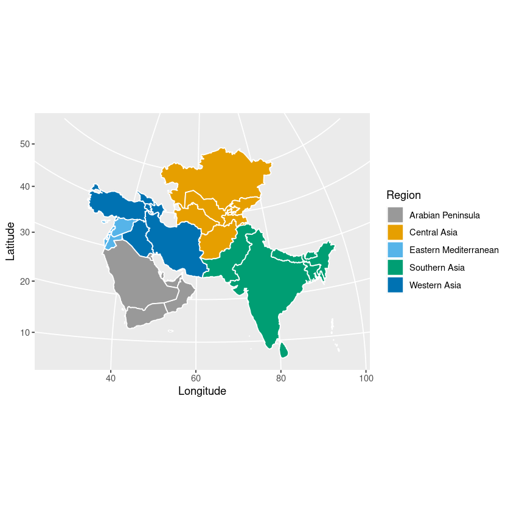

```r
ggplot(countries_map, aes(x = long, y = lat, fill = Region)) +
    geom_polygon(aes(group = group), color = 'white') +
    scale_fill_manual(values = cbPalette) +
    coord_map('polyconic') +
    xlab('Longitude') +
    ylab('Latitude')
```

# Diversities

## Richness, Shannon, Greenberg, and HCDT

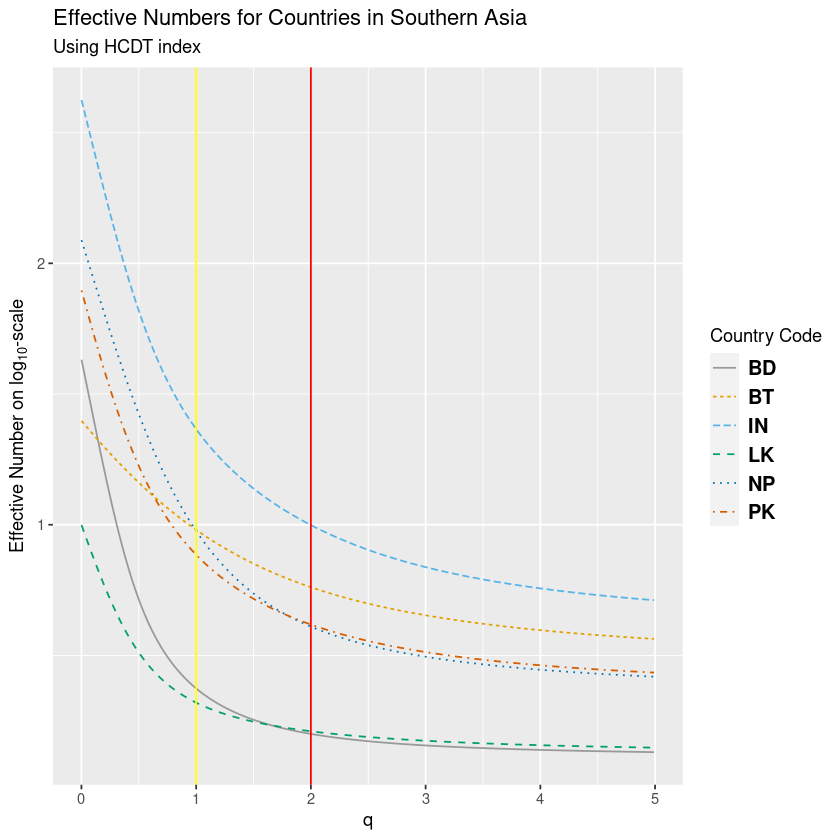

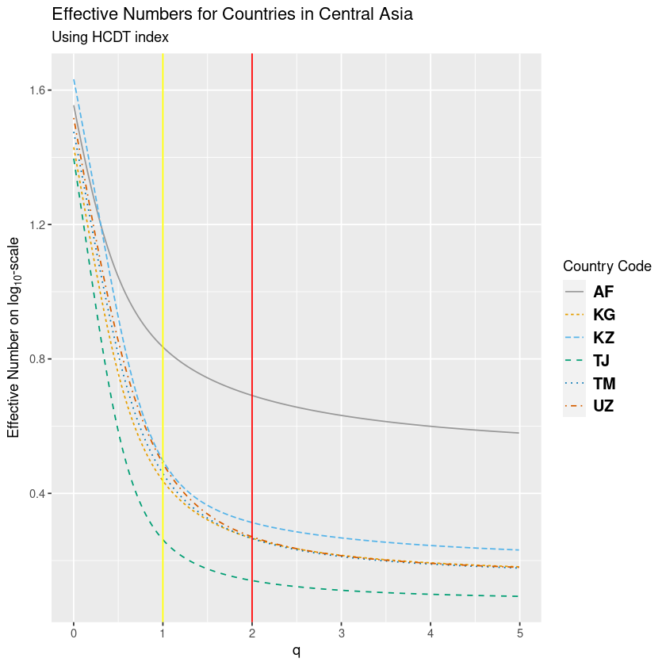

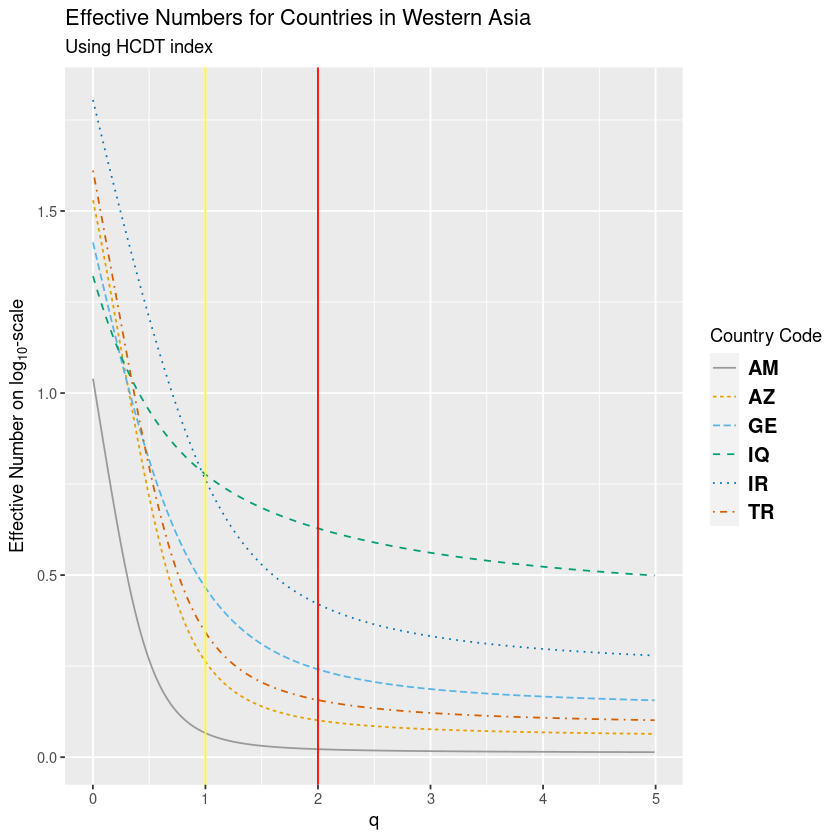

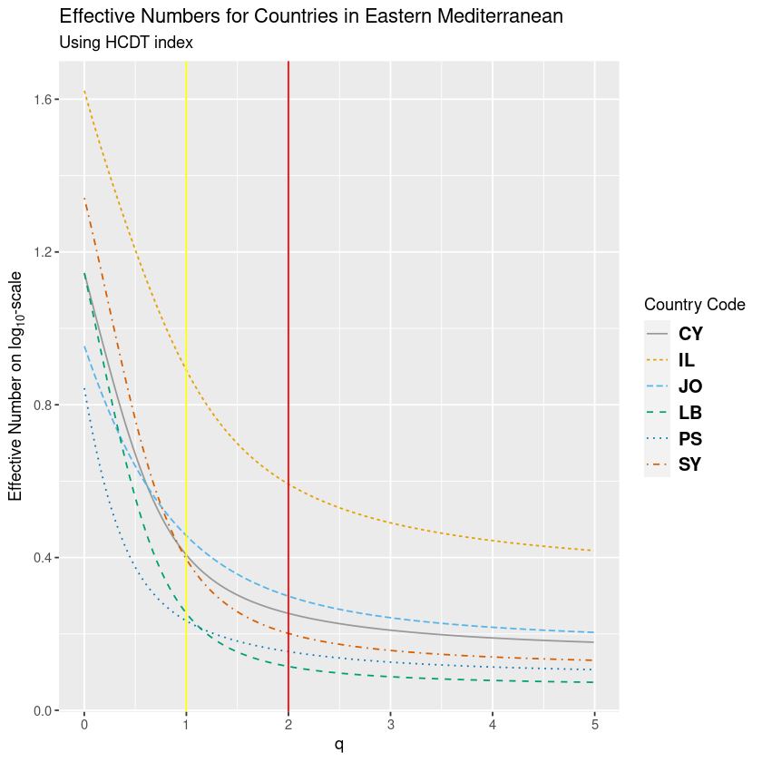

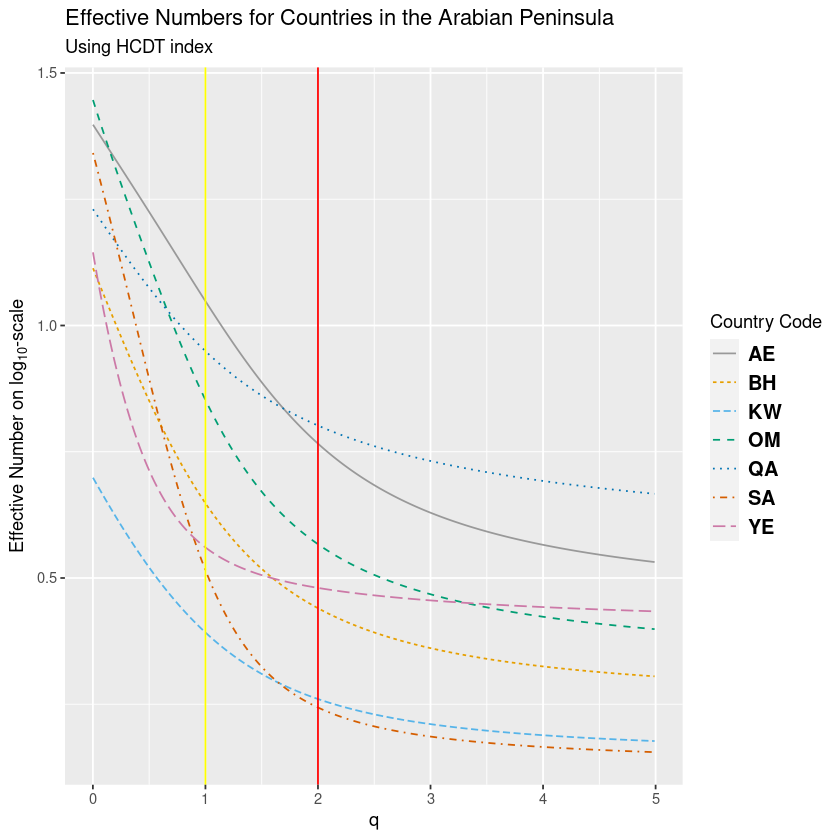

```r
# effective numbers for HCDT index, for 0 < q < 5
main <- rbind(main_1, main_2)

for (region in unique(main_tbl$Region_New)) {

    print(main %>%
              filter(Region_New == region) %>%
              ggplot(aes(x = q, y = log10(Diversity))) +
              geom_line(aes(linetype = Country_Code, color = Country_Code)) +
              geom_vline(xintercept = 1, color = 'yellow') +
              geom_vline(xintercept = 2, color = 'red') +
              scale_color_manual(values = cbPalette) +
              labs(title = paste('Effective Numbers for Countries in', region),
                   subtitle = 'Using HCDT index',
                   linetype = 'Country Code',
                   color = 'Country Code') +
              xlab('q') +
              ylab(TeX('Effective Number on $\\log_{10}$-scale')) +
              theme(legend.text = element_text(size = 12, face = 'bold')))

}
```

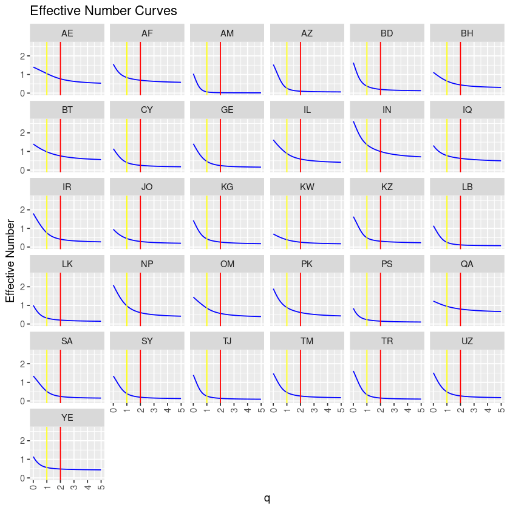

```r
main %>%
    ggplot(aes(x = q, y = log10(Diversity))) +
    geom_line(color = 'blue') +
    geom_vline(xintercept = 1, color = 'yellow') +
    geom_vline(xintercept = 2, color = 'red') +
    facet_wrap(vars(Country_Code)) +
    scale_color_manual(values = cbPalette) +
    labs(title = 'Effective Number Curves') +
    xlab('q') +
    ylab('Effective Number') +
    theme(axis.text.x = element_text(angle = 90, hjust = 1, vjust = 0.5))
```

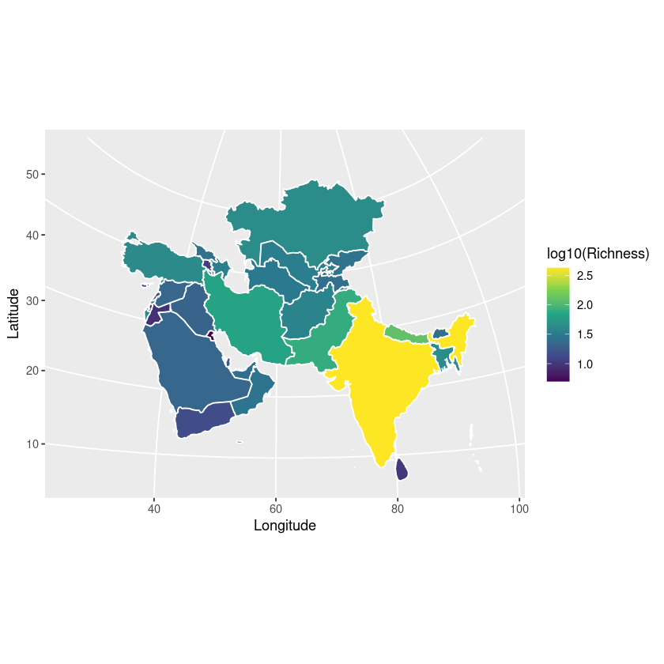

```r
ggplot(countries_map_df, aes(x = long, y = lat)) +
    geom_polygon(aes(group = group, fill = log10(Richness)), color = 'white') +
    scale_fill_viridis_c() +
    coord_map('polyconic') +
    xlab('Longitude') +
    ylab('Latitude')
```

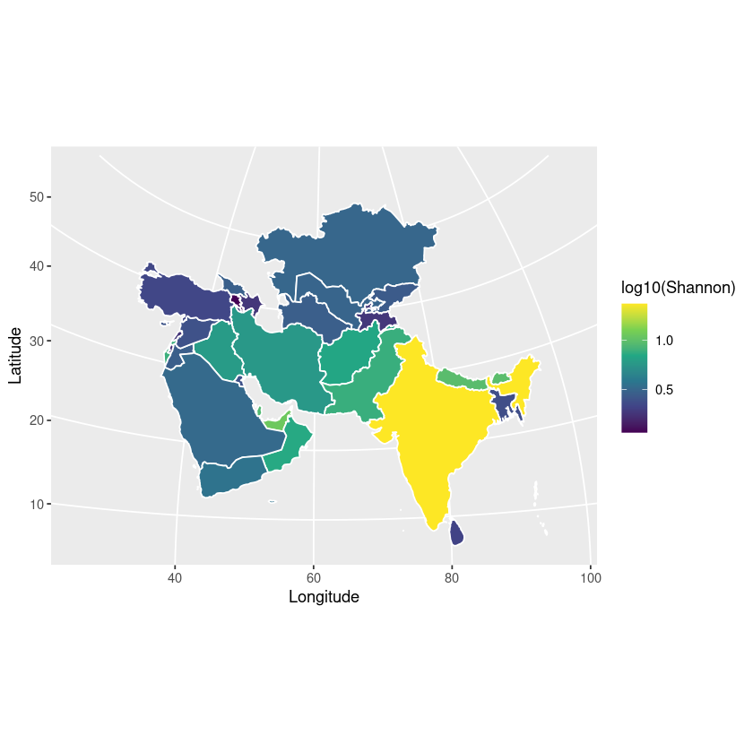

```r
ggplot(countries_map_df, aes(x = long, y = lat)) +
    geom_polygon(aes(group = group, fill = log10(Shannon)), color = 'white') +
    scale_fill_viridis_c() +
    coord_map('polyconic') +
    xlab('Longitude') +
    ylab('Latitude')
```

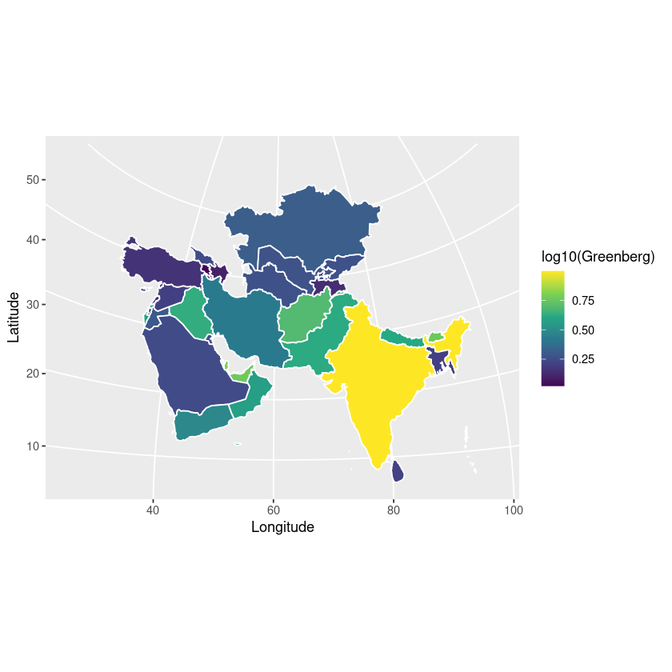

```r
ggplot(countries_map_df, aes(x = long, y = lat)) +
    geom_polygon(aes(group = group, fill = log10(Greenberg)), color = 'white') +
    scale_fill_viridis_c() +
    coord_map('polyconic') +
    xlab('Longitude') +
    ylab('Latitude')
```

```r
suppressMessages(animate(map_with_animation, nframes = num_qs, fps = 2))
```

[output not shown]

# Gamma Diversities

### Unweighted Gamma Diversities

```r
giml_df <- compact_df %>%
    group_by(Country_Code) %>%
    mutate(Country_Pop = sum(L1_Users)) %>%
    ungroup()

giml_u_m <- giml_df %>%
    mutate(Total_Pop = sum(L1_Users),
           Prop = L1_Users / Country_Pop,
           Weight = 1 / N)

giml_u_m <- giml_u_m %>%
    select(-Country_Code) %>%
    group_by(ISO_639) %>%
    mutate(Weighted_Prop = sum(Prop * Weight)) %>%
    ungroup() %>%
    select(ISO_639, Weighted_Prop) %>%
    unique()

giml_u_m <- giml_u_m %>%
    summarise(Gamma_Richness = n(),
              Gamma_Shannon = exp(-sum(Weighted_Prop * log(Weighted_Prop))),
              Gamma_Greenberg = 1 / sum(Weighted_Prop ** 2))

giml_u_m
```

A tibble: 1 × 3

| Gamma_Richness <int> | Gamma_Shannon <dbl> | Gamma_Greenberg <dbl> |
| --- | --- | --- |
| 790 | 59.52642 | 37.82071 |

### Weighted Gamma Diversities

```r
giml_w_m <- giml_df %>%
    mutate(Total_Pop = sum(L1_Users),
           Prop = L1_Users / Country_Pop,
           Weight = Country_Pop / Total_Pop)

giml_w_m <- giml_w_m %>%
    select(-Country_Code) %>%
    group_by(ISO_639) %>%
    mutate(Weighted_Prop = sum(Prop * Weight)) %>%
    ungroup() %>%
    select(ISO_639, Weighted_Prop) %>%
    unique()

giml_w_m <- giml_w_m %>%
    summarise(Gamma_Richness = n(),
              Gamma_Shannon = exp(-sum(Weighted_Prop * log(Weighted_Prop))),
              Gamma_Greenberg = 1 / sum(Weighted_Prop ** 2))

giml_w_m
```

A tibble: 1 × 3

| Gamma_Richness <int> | Gamma_Shannon <dbl> | Gamma_Greenberg <dbl> |
| --- | --- | --- |
| 790 | 48.44389 | 19.37289 |

# Alpha Diversities

### Unweighted Alpha Diversities

```r
alep_df <- compact_df %>% mutate(Total_Pop = sum(L1_Users))

alep_u_m <- alep_df %>%
    group_by(Country_Code) %>%
    mutate(Pop = sum(L1_Users),
           Prop = L1_Users / Pop,
           Total_Prop = L1_Users / Total_Pop,
           Weight = 1 / N)

suppressMessages(alep_u_m <- alep_u_m %>%
                     summarise(Richness = n(),
                               Shannon = -sum(Prop * log(Prop)),
                               Greenberg = sum(Prop ** 2)) %>%
                     ungroup() %>%
                     unique())

alep_u_m <- alep_u_m %>%
    summarise(Alpha_Richness = mean(Richness),
              Alpha_Shannon = exp(mean(Shannon)),
              Alpha_Greenberg = 1 / mean(Greenberg))

alep_u_m
```

A tibble: 1 × 3

| Alpha_Richness <dbl> | Alpha_Shannon <dbl> | Alpha_Greenberg <dbl> |
| --- | --- | --- |
| 42.77419 | 3.854177 | 2.138338 |

### Weighted Alpha Diversities

```r
alep_df <- compact_df %>% mutate(Total_Pop = sum(L1_Users))

alep_w_m <- alep_df %>%
    group_by(Country_Code) %>%
    mutate(Country_Pop = sum(L1_Users),
           Prop = L1_Users / Country_Pop,
           Weight = Country_Pop / Total_Pop,
           Richness = n(),
           Shannon = -sum(Prop * log(Prop)),
           Greenberg = sum(Prop ** 2)) %>%
    ungroup() %>%
    select(Country_Code,
           Richness,
           Shannon,
           Greenberg,
           Country_Pop,
           Total_Pop,
           Weight) %>%
    unique()

suppressMessages(alep_w_m <- alep_w_m %>%
                     summarise(Alpha_Richness = mean(Richness),
                               Alpha_Shannon = exp(sum(Shannon * Weight)),
                               Alpha_Greenberg = sum(Weight ** 2) / sum(Weight ** 2 * Greenberg )))

alep_w_m
```

A tibble: 1 × 3

| Alpha_Richness <dbl> | Alpha_Shannon <dbl> | Alpha_Greenberg <dbl> |
| --- | --- | --- |
| 42.77419 | 11.56583 | 8.508196 |

# Beta Diversities

### Unweighted Beta Diversities

```r
bet_u_m <- giml_u_m / alep_u_m

names(bet_u_m) <- c('Beta_Richness', 'Beta_Shannon', 'Beta_Greenberg')

bet_u_m
```

A data.frame: 1 × 3

| Beta_Richness <dbl> | Beta_Shannon <dbl> | Beta_Greenberg <dbl> |
| --- | --- | --- |
| 18.46908 | 15.44465 | 17.68697 |

### Weighted Beta Diversities

```r
bet_w_m <- giml_w_m / alep_w_m

names(bet_w_m) <- c('Beta_Richness', 'Beta_Shannon', 'Beta_Greenberg')

bet_w_m
```

A data.frame: 1 × 3

| Beta_Richness <dbl> | Beta_Shannon <dbl> | Beta_Greenberg <dbl> |
| --- | --- | --- |
| 18.46908 | 4.188535 | 2.276968 |

# Visualizing Diversities

### Visualizing Unweighted Gamma Diversity

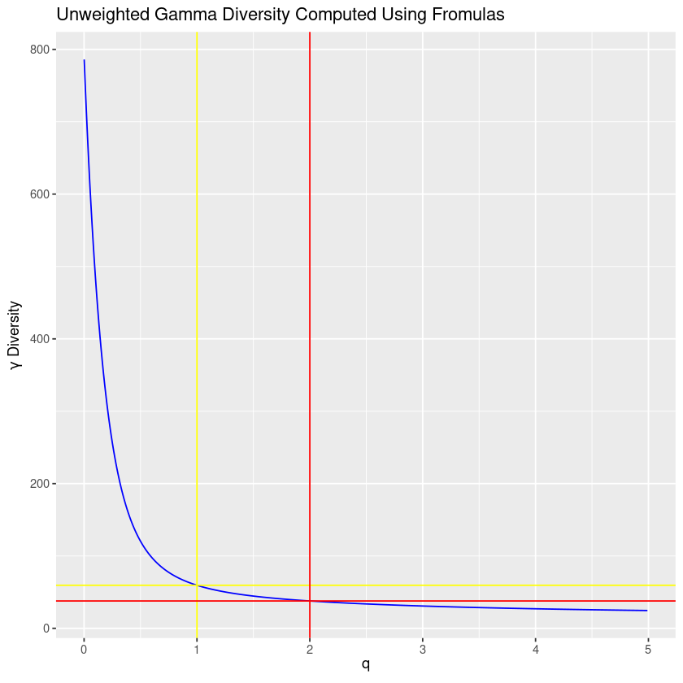

```r
qsum_g_u_m <- rbind(qsum1_g_u_m, qsum2_g_u_m)

print(qsum_g_u_m %>%
          ggplot(aes(x = q, y = Giml_Manual)) +
          geom_line( color = 'blue') +
          geom_hline(yintercept = giml_u_m$Gamma_Shannon, color = 'yellow') +
          geom_vline(xintercept = 1, color = 'yellow') +
          geom_hline(yintercept = giml_u_m$Gamma_Greenberg, color = 'red') +
          geom_vline(xintercept = 2, color = 'red') +
          labs(title = 'Unweighted Gamma Diversity Computed Using Fromulas') +
          xlab(TeX('$q$')) +
          ylab(TeX('$\\gamma$ Diversity')))
```

### Visualizing Weighted Gamma Diversity

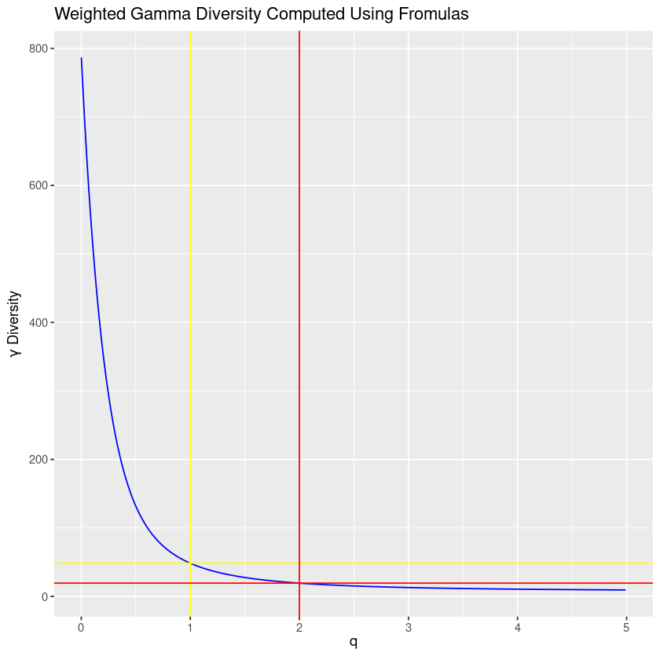

```r
qsum_g_w_m <- rbind(qsum1_g_w_m, qsum2_g_w_m)

print(qsum_g_w_m %>%
          ggplot(aes(x = q, y = Giml_Manual)) +
          geom_line( color = 'blue') +
          geom_hline(yintercept = giml_w_m$Gamma_Shannon, color = 'yellow') +
          geom_vline(xintercept = 1, color = 'yellow') +
          geom_hline(yintercept = giml_w_m$Gamma_Greenberg, color = 'red') +
          geom_vline(xintercept = 2, color = 'red') +
          labs(title = 'Weighted Gamma Diversity Computed Using Fromulas') +
          xlab(TeX('$q$')) +
          ylab(TeX('$\\gamma$ Diversity')))
```

### Visualizing Unweighted Alpha Diversity

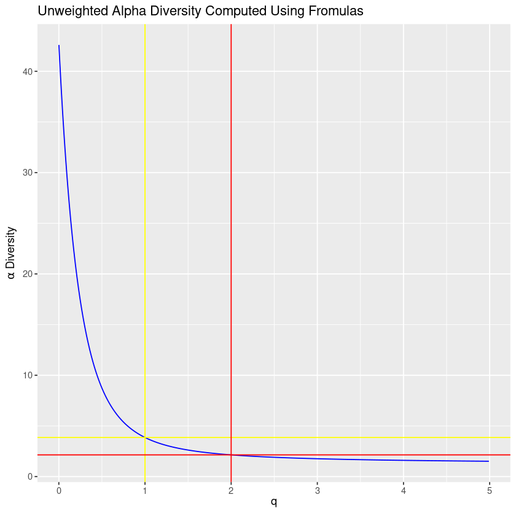

```r
qsum_a_u_m <- rbind(qsum1_a_u_m, qsum2_a_u_m)

print(qsum_a_u_m %>%
          ggplot(aes(x = q, y = Alep_Manual)) +
          geom_line( color = 'blue') +
          geom_hline(yintercept = alep_u_m$Alpha_Shannon, color = 'yellow') +
          geom_vline(xintercept = 1, color = 'yellow') +
          geom_hline(yintercept = alep_u_m$Alpha_Greenberg, color = 'red') +
          geom_vline(xintercept = 2, color = 'red') +
          labs(title = 'Unweighted Alpha Diversity Computed Using Fromulas') +
          xlab(TeX('$q$')) +
          ylab(TeX('$\\alpha$ Diversity')))
```

### Visualizing Weighted Alpha Diversity

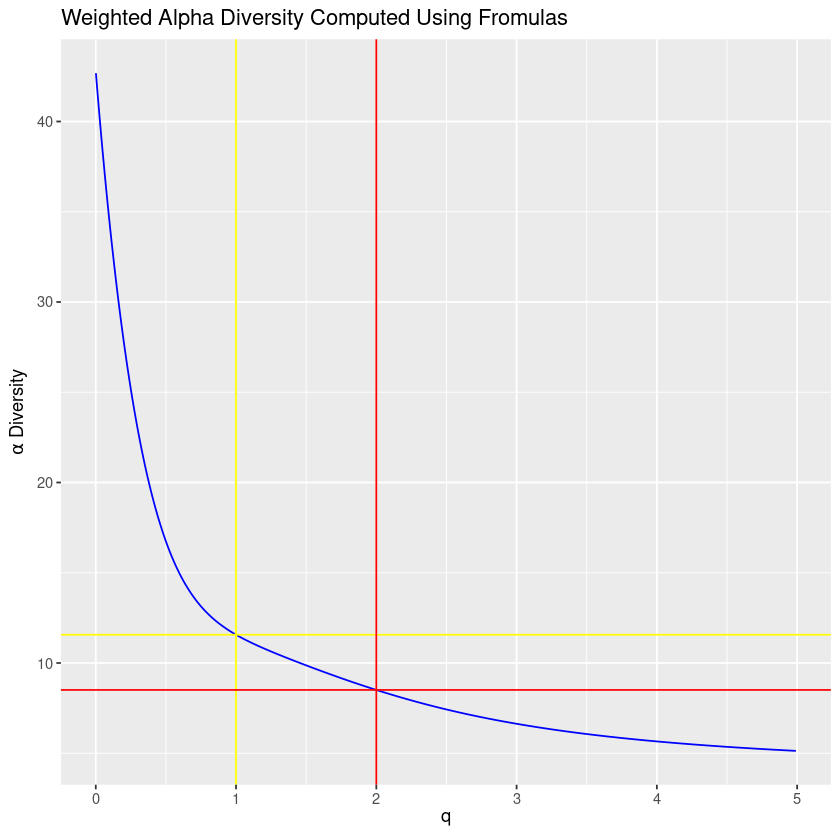

```r
qsum_a_w_m <- rbind(qsum1_a_w_m, qsum2_a_w_m)

print(qsum_a_w_m %>%
          ggplot(aes(x = q, y = Alep_Manual)) +
          geom_line( color = 'blue') +
          geom_hline(yintercept = alep_w_m$Alpha_Shannon, color = 'yellow') +
          geom_vline(xintercept = 1, color = 'yellow') +
          geom_hline(yintercept = alep_w_m$Alpha_Greenberg, color = 'red') +
          geom_vline(xintercept = 2, color = 'red') +
          labs(title = 'Weighted Alpha Diversity Computed Using Fromulas') +
          xlab(TeX('$q$')) +
          ylab(TeX('$\\alpha$ Diversity')))
```

### Visualizing Unweighted Beta Diversity

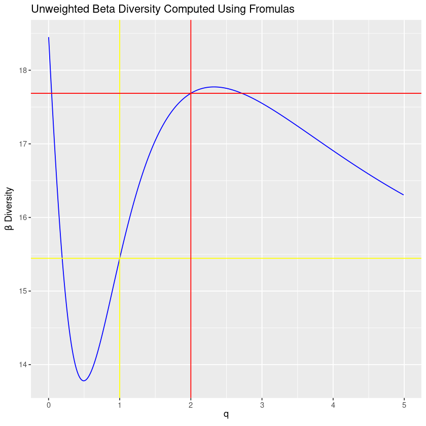

```r
qsum_b_u_m <- rbind(qsum1_b_u_m, qsum2_b_u_m)


print(qsum_b_u_m %>%
          ggplot(aes(x = q, y = Bet_Manual)) +
          geom_line( color = 'blue') +
          geom_hline(yintercept = bet_u_m$Beta_Shannon, color = 'yellow') +
          geom_vline(xintercept = 1, color = 'yellow') +
          geom_hline(yintercept = bet_u_m$Beta_Greenberg, color = 'red') +
          geom_vline(xintercept = 2, color = 'red') +
          labs(title = 'Unweighted Beta Diversity Computed Using Fromulas') +
          xlab(TeX('$q$')) +
          ylab(TeX('$\\beta$ Diversity')))
```

### Visualizing Weighted Beta Diversity

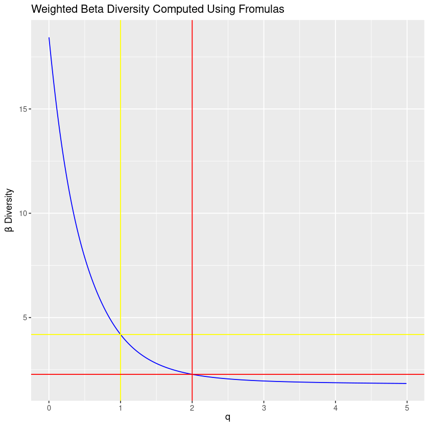

```r
qsum_b_w_m <- rbind(qsum1_b_w_m, qsum2_b_w_m)

print(qsum_b_w_m %>%
          ggplot(aes(x = q, y = Bet_Manual)) +
          geom_line( color = 'blue') +
          geom_hline(yintercept = bet_w_m$Beta_Shannon, color = 'yellow') +
          geom_vline(xintercept = 1, color = 'yellow') +
          geom_hline(yintercept = bet_w_m$Beta_Greenberg, color = 'red') +
          geom_vline(xintercept = 2, color = 'red') +
          labs(title = 'Weighted Beta Diversity Computed Using Fromulas') +
          xlab(TeX('$q$')) +
          ylab(TeX('$\\beta$ Diversity')))
```

# MacArthur’s Homogeneity Measure

### Order 0 (Richness)

```r
alep_u_m$Alpha_Richness / giml_u_m$Gamma_Richness
```

0.0541445487954267

### Order 1 (Shannon)

```r
alep_u_m$Alpha_Shannon / giml_u_m$Gamma_Shannon
```

0.0647473363555292

### Order 2 (Greenberg)

```r
alep_u_m$Alpha_Greenberg / giml_u_m$Gamma_Greenberg
```

0.0565388040867703

# Relative Homogeneity

## Unweighted

```r
homog_u_m <- data.frame(list((1 / bet_u_m$Beta_Richness - 1 / N) / (1 - 1 / N),
                             (1 / bet_u_m$Beta_Shannon - 1 / N) / (1 - 1 / N),
                             (1 / bet_u_m$Beta_Greenberg - 1 / N) / (1 - 1 / N)))

names(homog_u_m) <- c('Order 0 Homogeneity',
                      'Order 1 Homogeneity',
                      'Order 2 Homogeneity')

homog_u_m
```

A data.frame: 1 × 3

| Order 0 Homogeneity <dbl> | Order 1 Homogeneity <dbl> | Order 2 Homogeneity <dbl> |
| --- | --- | --- |
| 0.02261603 | 0.03357225 | 0.0250901 |

## Weighted

```r
weights <- unique(giml$Weight)

d_1_w_m <- exp(-sum(weights * log(weights)))

(1 / bet_w_m$Beta_Shannon - 1 / d_1_w_m) / (1 - 1 / d_1_w_m)
```

0.0664517050620584

# Sørensen-Dice and Jaccard Indices

## Sørensen-Dice

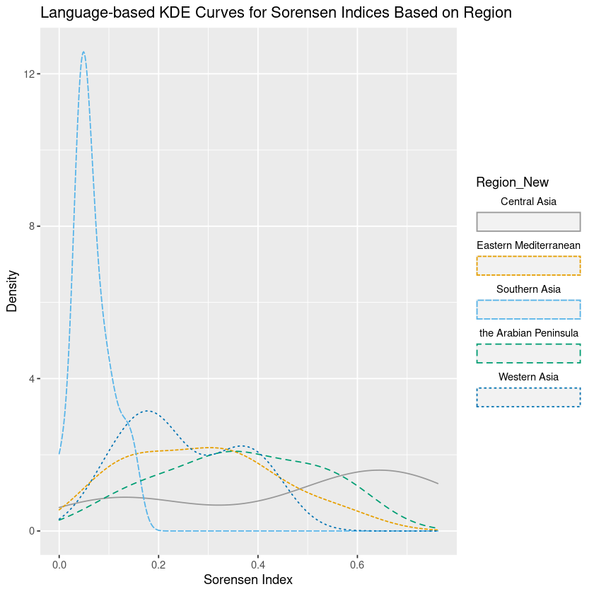

```r
sorensen %>%
    ggplot(aes(x = Sorensen_Language, color = Region_New)) +
    geom_density(aes(linetype = Region_New)) +
    scale_color_manual(values = cbPalette) +
    labs(title = 'Language-based KDE Curves for Sorensen Indices Based on Region') +
    ylab('Density') +
    xlab('Sorensen Index') +
    guides(color = guide_legend(label.position = 'top'))
```

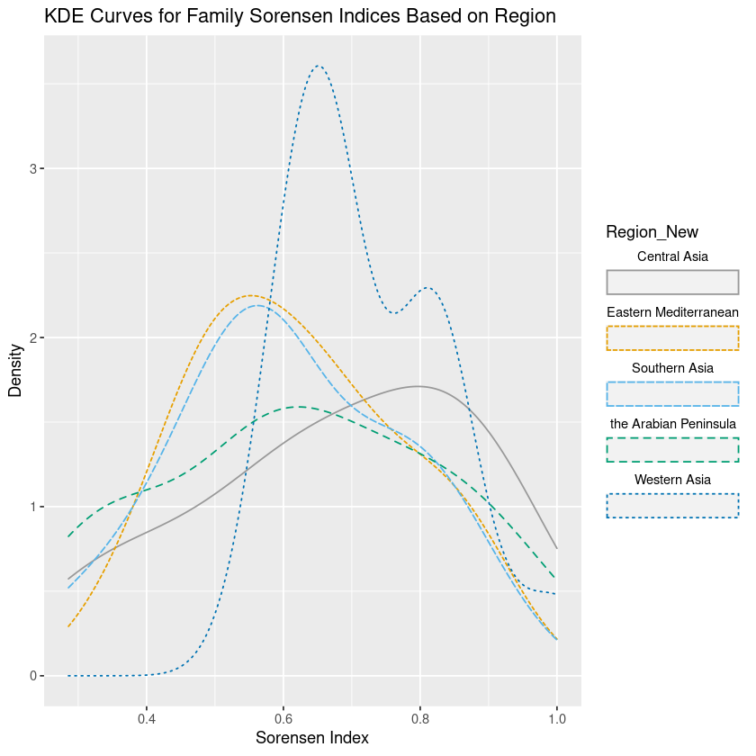

```r
sorensen %>%
    ggplot(aes(x = Sorensen_Family, color = Region_New)) +
    geom_density(aes(linetype = Region_New)) +
    scale_color_manual(values = cbPalette) +
    labs(title = 'KDE Curves for Family Sorensen Indices Based on Region') +
    ylab('Density') +
    xlab('Sorensen Index') +
    guides(color = guide_legend(label.position = 'top'))
```

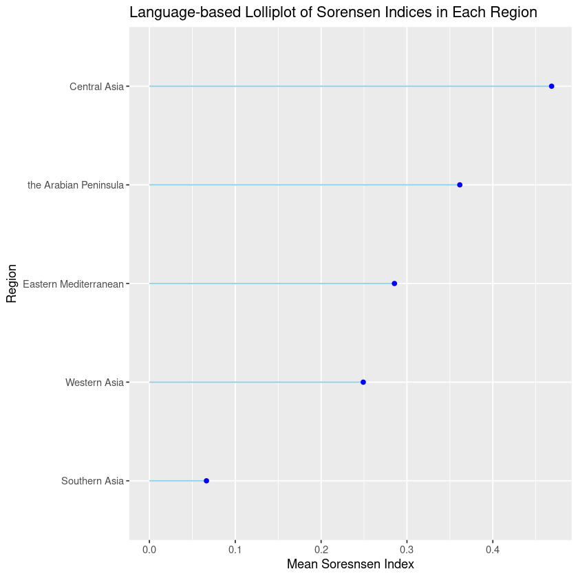

```r
suppressMessages(sorensen %>% group_by(Region_New) %>%
    summarize(Mean_Sorensen_Language = mean(Sorensen_Language),
              Mean_Sorensen_Family = mean(Sorensen_Family)) %>%
    ggplot(aes(x = Mean_Sorensen_Language, y = reorder(Region_New, Mean_Sorensen_Language))) +
    geom_segment(aes(x = 0,
                     xend = Mean_Sorensen_Language,
                     y = reorder(Region_New, Mean_Sorensen_Language),
                     yend = reorder(Region_New, Mean_Sorensen_Language)),
                     color = 'skyblue') +
    geom_point(show.legend = FALSE, color = 'blue') +
    labs(title = 'Language-based Lolliplot of Sorensen Indices in Each Region') +
    ylab('Region') +
    xlab('Mean Soresnsen Index'))
```

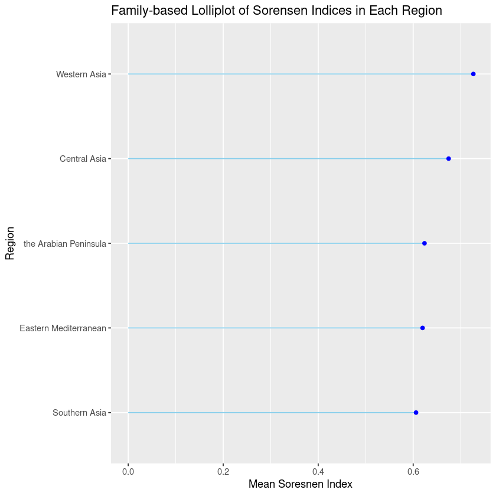

```r
suppressMessages(sorensen %>% group_by(Region_New) %>%
    summarize(Mean_Sorensen_Language = mean(Sorensen_Language),
              Mean_Sorensen_Family = mean(Sorensen_Family)) %>%
    ggplot(aes(x = Mean_Sorensen_Family, y = reorder(Region_New, Mean_Sorensen_Family))) +
    geom_segment(aes(x = 0,
                     xend = Mean_Sorensen_Family,
                     y = reorder(Region_New, Mean_Sorensen_Family),
                     yend = reorder(Region_New, Mean_Sorensen_Family)),
                     color = 'skyblue') +
    geom_point(show.legend = FALSE, color = 'blue') +
    labs(title = 'Family-based Lolliplot of Sorensen Indices in Each Region') +
    ylab('Region') +
    xlab('Mean Soresnen Index'))
```

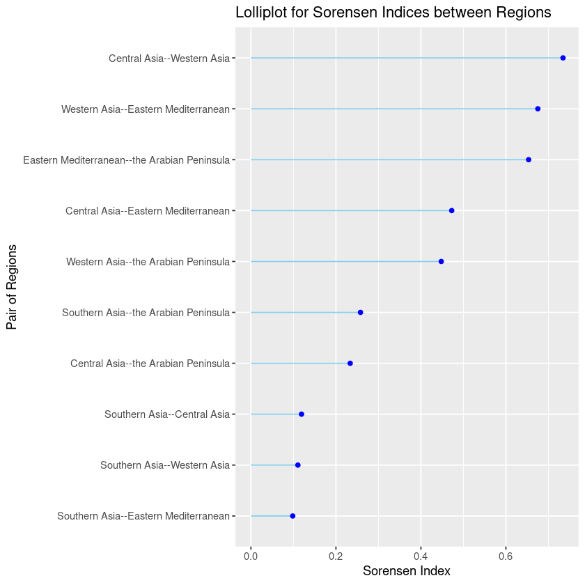

```r
sorensen_2 %>%
    ggplot(aes(x = Sorensen, y = reorder(Regions, Sorensen))) +
    geom_segment(aes(x = 0,
                     xend = Sorensen,
                     y = reorder(Regions, Sorensen),
                     yend = reorder(Regions, Sorensen)),
                     color = 'skyblue') +
    geom_point(show.legend = FALSE, color = 'blue') +
    labs(title = 'Lolliplot for Sorensen Indices between Regions') +
    ylab('Pair of Regions') +
    xlab('Sorensen Index')
```

## Jaccard

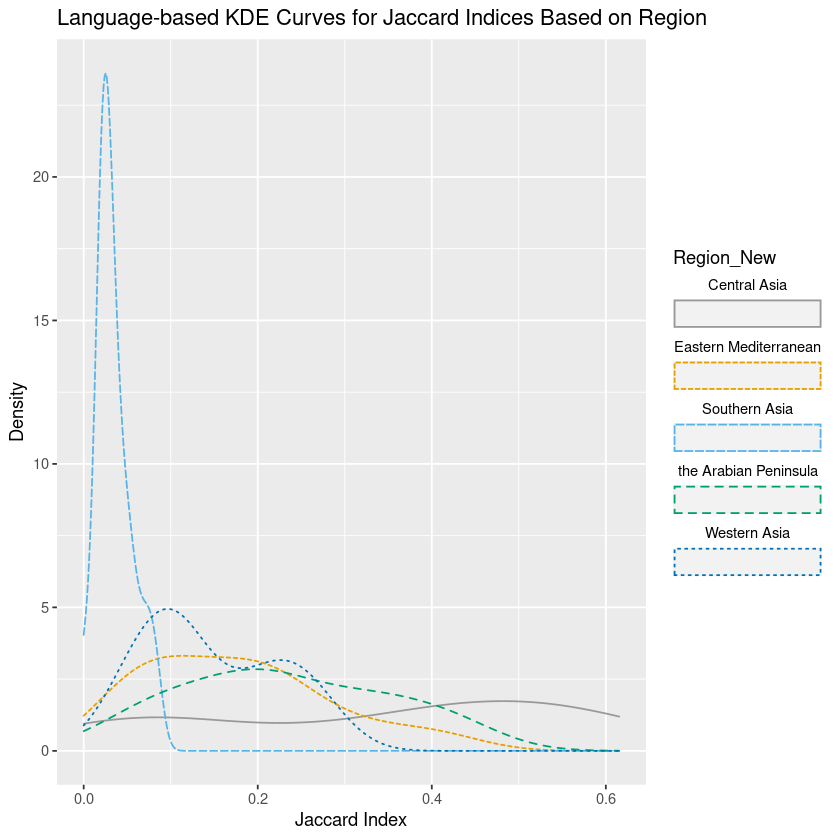

```r
jaccard %>%
    ggplot(aes(x = Jaccard_Language, color = Region_New)) +
    geom_density(aes(linetype = Region_New)) +
    scale_color_manual(values = cbPalette) +
    labs(title = 'Language-based KDE Curves for Jaccard Indices Based on Region') +
    ylab('Density') +
    xlab('Jaccard Index') +
    guides(color = guide_legend(label.position = 'top'))
```

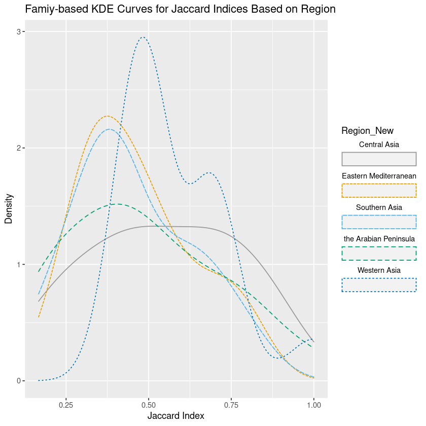

```r
jaccard %>%
    ggplot(aes(x = Jaccard_Family, color = Region_New)) +
    geom_density(aes(linetype = Region_New)) +
    scale_color_manual(values = cbPalette) +
    labs(title = 'Famiy-based KDE Curves for Jaccard Indices Based on Region') +
    ylab('Density') +
    xlab('Jaccard Index') +
    guides(color = guide_legend(label.position = 'top'))
```

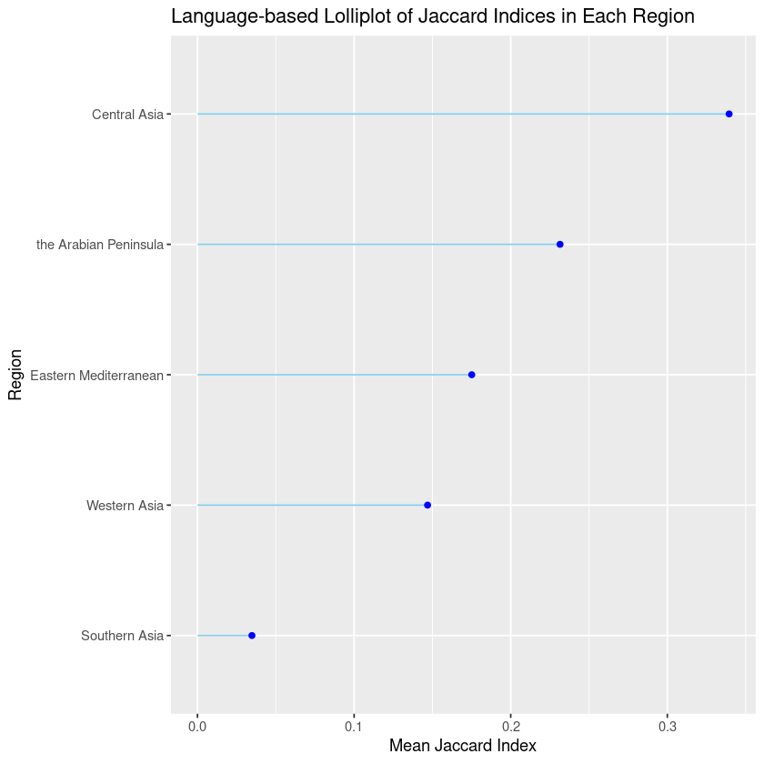

```r
suppressMessages(jaccard %>% group_by(Region_New) %>%
    summarize(Mean_Jaccard_Language = mean(Jaccard_Language),
              Mean_Jaccard_Family = mean(Jaccard_Family)) %>%
    ggplot(aes(x = Mean_Jaccard_Language, y = reorder(Region_New, Mean_Jaccard_Language))) +
    geom_segment(aes(x = 0,
                     xend = Mean_Jaccard_Language,
                     y = reorder(Region_New, Mean_Jaccard_Language),
                     yend = reorder(Region_New, Mean_Jaccard_Language)),
                     color = 'skyblue') +
    geom_point(show.legend = FALSE, color = 'blue') +
    labs(title = 'Language-based Lolliplot of Jaccard Indices in Each Region') +
    ylab('Region') +
    xlab('Mean Jaccard Index'))
```

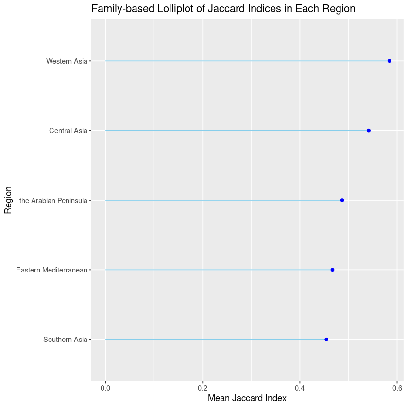

```r
suppressMessages(jaccard %>% group_by(Region_New) %>%
    summarize(Mean_Jaccard_Language = mean(Jaccard_Language),
              Mean_Jaccard_Family = mean(Jaccard_Family)) %>%
    ggplot(aes(x = Mean_Jaccard_Family, y = reorder(Region_New, Mean_Jaccard_Family))) +
    geom_segment(aes(x = 0,
                     xend = Mean_Jaccard_Family,
                     y = reorder(Region_New, Mean_Jaccard_Family),
                     yend = reorder(Region_New, Mean_Jaccard_Family)),
                     color = 'skyblue') +
    geom_point(show.legend = FALSE, color = 'blue') +
    labs(title = 'Family-based Lolliplot of Jaccard Indices in Each Region') +
    ylab('Region') +
    xlab('Mean Jaccard Index'))
```

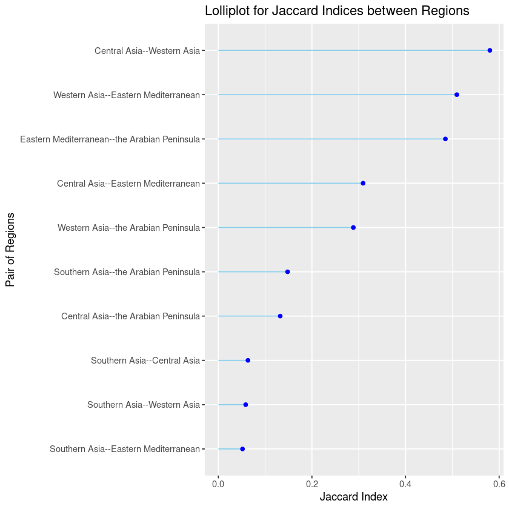

```r
jaccard_2 %>%
    ggplot(aes(x = Jaccard, y = reorder(Regions, Jaccard))) +
    geom_segment(aes(x = 0,
                     xend = Jaccard,
                     y = reorder(Regions, Jaccard),
                     yend = reorder(Regions, Jaccard)),
                     color = 'skyblue') +
    geom_point(show.legend = FALSE, color = 'blue') +
    labs(title = 'Lolliplot for Jaccard Indices between Regions') +
    ylab('Pair of Regions') +
    xlab('Jaccard Index')
```